# **Titanic DataSet Analysis Using Numpy and Pandas**

**NAME - SYED MIRAN, YASMIN SANIYA**

**CLASS - CSD 2ND YEAR**

**ROLL NUMBER - 160921750038, 160921750046**

**ASSIGNMENT - 3**

```python
import numpy as np
import pandas as pd
import matplotlib.pyplot as plt
import seaborn as sns
```

**Loading Data Set**

```python
df = pd.read_csv('/content/train.csv')
df.head()
```

|  | PassengerId | Survived | Pclass | Name | Sex | Age | SibSp | Parch | Ticket | Fare | Cabin | Embarked |
| --- | --- | --- | --- | --- | --- | --- | --- | --- | --- | --- | --- | --- |
| 0 | 1 | 0 | 3 | Braund, Mr. Owen Harris | male | 22.0 | 1 | 0 | A/5 21171 | 7.2500 | NaN | S |
| 1 | 2 | 1 | 1 | Cumings, Mrs. John Bradley (Florence Briggs Th... | female | 38.0 | 1 | 0 | PC 17599 | 71.2833 | C85 | C |
| 2 | 3 | 1 | 3 | Heikkinen, Miss. Laina | female | 26.0 | 0 | 0 | STON/O2. 3101282 | 7.9250 | NaN | S |
| 3 | 4 | 1 | 1 | Futrelle, Mrs. Jacques Heath (Lily May Peel) | female | 35.0 | 1 | 0 | 113803 | 53.1000 | C123 | S |
| 4 | 5 | 0 | 3 | Allen, Mr. William Henry | male | 35.0 | 0 | 0 | 373450 | 8.0500 | NaN | S |

```python
df.info()
```

```
<class 'pandas.core.frame.DataFrame'>
RangeIndex: 891 entries, 0 to 890
Data columns (total 12 columns):
 #   Column       Non-Null Count  Dtype
---  ------       --------------  -----
 0   PassengerId  891 non-null    int64
 1   Survived     891 non-null    int64
 2   Pclass       891 non-null    int64
 3   Name         891 non-null    object
 4   Sex          891 non-null    object
 5   Age          714 non-null    float64
 6   SibSp        891 non-null    int64
 7   Parch        891 non-null    int64
 8   Ticket       891 non-null    object
 9   Fare         891 non-null    float64
 10  Cabin        204 non-null    object
 11  Embarked     889 non-null    object
dtypes: float64(2), int64(5), object(5)
memory usage: 83.7+ KB
```

```python
df.shape
```

```
(891, 12)
```

```python
df.columns
```

```
Index(['PassengerId', 'Survived', 'Pclass', 'Name', 'Sex', 'Age', 'SibSp',
       'Parch', 'Ticket', 'Fare', 'Cabin', 'Embarked'],
      dtype='object')
```

**Lets remove unnecessary columns which we are'nt gonna use**

```python
df = df.drop(['Ticket',	'Fare',	'Cabin'], axis =1)
df.head()
```

|  | PassengerId | Survived | Pclass | Name | Sex | Age | SibSp | Parch | Embarked |
| --- | --- | --- | --- | --- | --- | --- | --- | --- | --- |
| 0 | 1 | 0 | 3 | Braund, Mr. Owen Harris | male | 22.0 | 1 | 0 | S |
| 1 | 2 | 1 | 1 | Cumings, Mrs. John Bradley (Florence Briggs Th... | female | 38.0 | 1 | 0 | C |
| 2 | 3 | 1 | 3 | Heikkinen, Miss. Laina | female | 26.0 | 0 | 0 | S |
| 3 | 4 | 1 | 1 | Futrelle, Mrs. Jacques Heath (Lily May Peel) | female | 35.0 | 1 | 0 | S |
| 4 | 5 | 0 | 3 | Allen, Mr. William Henry | male | 35.0 | 0 | 0 | S |

```python
df.info()
```

```
<class 'pandas.core.frame.DataFrame'>
RangeIndex: 891 entries, 0 to 890
Data columns (total 9 columns):
 #   Column       Non-Null Count  Dtype
---  ------       --------------  -----
 0   PassengerId  891 non-null    int64
 1   Survived     891 non-null    int64
 2   Pclass       891 non-null    int64
 3   Name         891 non-null    object
 4   Sex          891 non-null    object
 5   Age          714 non-null    float64
 6   SibSp        891 non-null    int64
 7   Parch        891 non-null    int64
 8   Embarked     889 non-null    object
dtypes: float64(1), int64(5), object(3)
memory usage: 62.8+ KB
```

```python
df2 = df[["Age"]].mean()
print(df2)
```

```
Age    29.699118
dtype: float64
```

**Average age of passengers boarding titanic was 29**

```python
df.Age.isnull().sum()
```

```
177
```

```python
df['Age'].fillna(df['Age'].mean(), inplace = True)
```

```python
df['Age'].isnull().sum()
```

```
0
```

```python
df.info()
```

```
<class 'pandas.core.frame.DataFrame'>
RangeIndex: 891 entries, 0 to 890
Data columns (total 9 columns):
 #   Column       Non-Null Count  Dtype
---  ------       --------------  -----
 0   PassengerId  891 non-null    int64
 1   Survived     891 non-null    int64
 2   Pclass       891 non-null    int64
 3   Name         891 non-null    object
 4   Sex          891 non-null    object
 5   Age          891 non-null    float64
 6   SibSp        891 non-null    int64
 7   Parch        891 non-null    int64
 8   Embarked     889 non-null    object
dtypes: float64(1), int64(5), object(3)
memory usage: 62.8+ KB
```

**Finally we can conclude that this raw data has been cleaned for futher analysis**

```python
df.head()
```

|  | PassengerId | Survived | Pclass | Name | Sex | Age | SibSp | Parch | Embarked |
| --- | --- | --- | --- | --- | --- | --- | --- | --- | --- |
| 0 | 1 | 0 | 3 | Braund, Mr. Owen Harris | male | 22.0 | 1 | 0 | S |
| 1 | 2 | 1 | 1 | Cumings, Mrs. John Bradley (Florence Briggs Th... | female | 38.0 | 1 | 0 | C |
| 2 | 3 | 1 | 3 | Heikkinen, Miss. Laina | female | 26.0 | 0 | 0 | S |
| 3 | 4 | 1 | 1 | Futrelle, Mrs. Jacques Heath (Lily May Peel) | female | 35.0 | 1 | 0 | S |
| 4 | 5 | 0 | 3 | Allen, Mr. William Henry | male | 35.0 | 0 | 0 | S |

```python
df['Survived'].value_counts()
```

```
0    549
1    342
Name: Survived, dtype: int64
```

**Almost 342 passengers on the board survived**

```python
df['Pclass'].value_counts()
```

```
3    491
1    216
2    184
Name: Pclass, dtype: int64
```

```python
af = pd.DataFrame(df['Pclass'].value_counts())
af
```

|  | Pclass |
| --- | --- |
| 3 | 491 |
| 1 | 216 |
| 2 | 184 |

**Here, 216 Passengers were on board in First class, followed by 184 passengers in second class and 491 passengers in third class.**

```python
df['Sex'].value_counts()
```

```
male      577
female    314
Name: Sex, dtype: int64
```

```python
sf = pd.DataFrame(df['Sex'].value_counts())
sf.head()
```

|  | Sex |
| --- | --- |
| male | 577 |
| female | 314 |

```python
df_males_death = 577
df_females_death = 314
```

**Here we can conclude that there were more males than females on the board**

```python
pd.pivot_table(df, index = 'Survived', values = ['Age','Sex'])
```

| Survived | Age |
| --- | --- |
| 0 | 30.415100 |
| 1 | 28.549778 |

```python
df_cat = df[['Survived','Pclass','Sex']]
df_cat
```

|  | Survived | Pclass | Sex |
| --- | --- | --- | --- |
| 0 | 0 | 3 | male |
| 1 | 1 | 1 | female |
| 2 | 1 | 3 | female |
| 3 | 1 | 1 | female |
| 4 | 0 | 3 | male |
| ... | ... | ... | ... |
| 886 | 0 | 2 | male |
| 887 | 1 | 1 | female |
| 888 | 0 | 3 | female |
| 889 | 1 | 1 | male |
| 890 | 0 | 3 | male |

891 rows × 3 columns

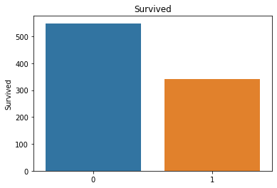

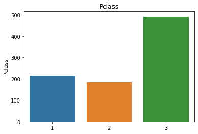

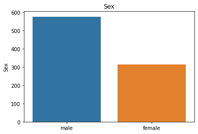

```python
for i in df_cat.columns:
    sns.barplot(df_cat[i].value_counts().index,df_cat[i].value_counts()).set_title(i)
    plt.show()
```

**Survived: Most of the people died in the shipwreck, only around 300 people survived. Pclass: The majority of the people traveling, had tickets to the 3rd class. Sex: There were more males than females aboard the ship, roughly double the amount**

```python
print(pd.pivot_table(df, index = 'Survived', columns = 'Sex',
                     aggfunc ='count'))
print()
```

```
            Age      Embarked        Name       Parch      PassengerId       \
Sex      female male   female male female male female male      female male
Survived
0            81  468       81  468     81  468     81  468          81  468
1           233  109      231  109    233  109    233  109         233  109

         Pclass       SibSp
Sex      female male female male
Survived
0            81  468     81  468
1           233  109    233  109
```

**Sex: Most of the women survived, and the majority of the male died in the shipwreck. So it looks like the saying “Woman and children first” actually applied in this scenario**

```python
df.head()
```

|  | PassengerId | Survived | Pclass | Name | Sex | Age | SibSp | Parch | Embarked |
| --- | --- | --- | --- | --- | --- | --- | --- | --- | --- |
| 0 | 1 | 0 | 3 | Braund, Mr. Owen Harris | male | 22.0 | 1 | 0 | S |
| 1 | 2 | 1 | 1 | Cumings, Mrs. John Bradley (Florence Briggs Th... | female | 38.0 | 1 | 0 | C |
| 2 | 3 | 1 | 3 | Heikkinen, Miss. Laina | female | 26.0 | 0 | 0 | S |
| 3 | 4 | 1 | 1 | Futrelle, Mrs. Jacques Heath (Lily May Peel) | female | 35.0 | 1 | 0 | S |
| 4 | 5 | 0 | 3 | Allen, Mr. William Henry | male | 35.0 | 0 | 0 | S |

```python
df['Embarked'].value_counts()
```

```
S    644
C    168
Q     77
Name: Embarked, dtype: int64
```

```python
emb = pd.DataFrame(df['Embarked'].value_counts())
emb
```

|  | Embarked |
| --- | --- |
| S | 644 |
| C | 168 |
| Q | 77 |

```python
qmb = 891
```

```python
dict_ = {'Southampton' : 644, 'Cherbourg' : 168, 'Queenstown' : 77}
Place = list(dict_.keys())
No_of_pass = list(dict_.values())
```

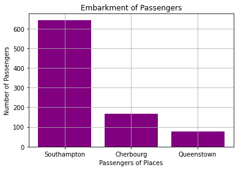

```python
plt.bar(Place, No_of_pass, color = 'purple' )
plt.title('Embarkment of Passengers')
plt.xlabel('Passengers of Places')
plt.ylabel('Number of Passengers')
plt.grid(True)
plt.show()
```

**As we can see majority of the passengers mounted from Southampton**

**THE END**

```python
!jupyter nbconvert --to html /content/titanic__.ipynb
```

```
[NbConvertApp] Converting notebook /content/titanic__.ipynb to html
[NbConvertApp] Writing 394130 bytes to /content/titanic__.html
```